# Experiment1: NYC airline data

```r
df5a <- df1 |>
  filter((time_hour >= "2013-06-21") & (time_hour <= "2013-09-22")) |>
  filter((dest == "ORD") | (dest == "MDW"))
df5
```

[output not shown]

[output cut: 990 more lines]

There were 5,843 flights to either Ohare airport or Midway airport from June 21, 2013 to September 21, 2013.

Task 6: Delays associated with flight number 86

Here we created a new variable “flight_nums” that only includes our target data, which are the flights to Miami in September. We then searched the “flight_nums” variable to find only the unique flight numbers. These unique flight numbers were then stored in the “flight_nums” variable.

```r
flight_nums <- df1 |> filter((month == 9) & (dest == "MIA"))
flight_nums <- unique(flight_nums$flight)
```

Then, we created a new variable “df6” which contained only the minimum flight number. In this case, the minimum flight number was 86, which we got using the min() function on the “flight_nums” variable, as well as setting the destination to only planes going to Miami.

```r
df6 <- df1 |>
  filter(flight == min(flight_nums), dest == "MIA")
```

Finally, we took the data in “df6” and created a visualization of department delays in relationship to arrival delays.

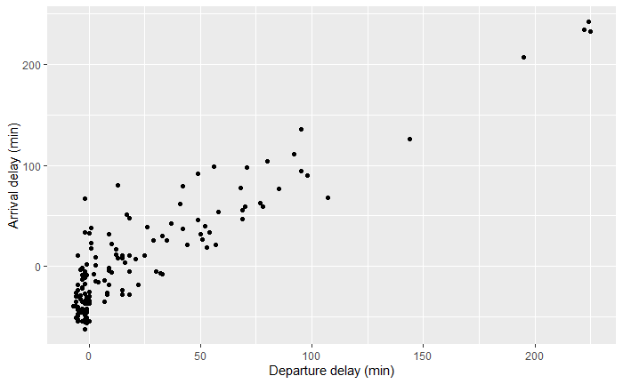

```r
  df6 |>
  ggplot(aes(x=dep_delay, y=arr_delay), ) +
  geom_point() +
  labs(y = "Arrival delay (min)", x = "Departure delay (min)")
```

Looking into the documentation of the “nycflights13” package, we can see that negative departure delay values indicate early departures and negative arrival delays indicate early arrivals. This information was taken from https://cran.r-project.org/web/packages/nycflights13/nycflights13.pdf, or it can be viewed in the documentation which can be pulled up in the help window by running the code below and loooking at the dep_delay, arr_delay section.

```r
?flights
```

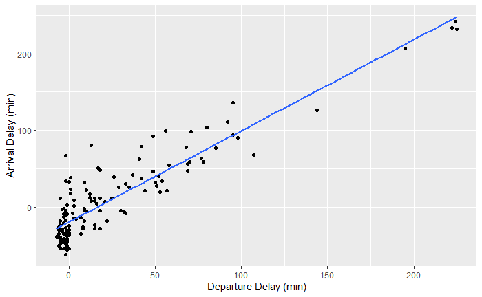

```r
ggplot(df6, aes(x = dep_delay, y=arr_delay)) +
  geom_point() +
  geom_smooth(method=lm, se=FALSE) +
  labs(x = "Departure Delay (min)", y = "Arrival Delay (min)")
```

This visualization adds a line of best fit to show that there is a positive correlation between Departure Time and Arrival Time. This shows us that generally, the longer the departure time is in minutes, the longer the arrival delay would be. This intuitively makes sense, since if you leave after you plan to, you will arrive later than you plan to, as the travel time of the flight is not effected by the departure time. It does not matter whether you leave at 1:00 pm or 1:40 pm, the duration of the flight will stay relatively consistent no matter what time you depart.